# Lecture 11: Non-proportional Hazards and Institutional Comparisons

STA310 Survival Analysis · Collett Chapter 11

2026-10-06

## Today

1. What non-proportional hazards look like
2. Why a single hazard ratio can mislead
3. Detecting non-PH (recap)
4. Options: stratification, time-varying effects, RMST and milestone survival, weighted log-rank, AFT
5. Institutional comparisons: case-mix adjustment, RAFR, funnel plots
6. Exercise and take-home

**Learning goals**

You can

- recognise and describe non-PH patterns
- explain why the Cox HR is an average that depends on follow-up
- choose among and fit alternatives to a single HR
- compute and interpret RMST differences
- compare institutions fairly, and know the limits of rankings

## Recap

- Cox model: $h(t \mid x) = h_0(t)\exp(\beta' x)$; the **hazard ratio is constant in time**
- Checks: log-minus-log plots, scaled Schoenfeld residuals, `cox.zph()` (recap of lecture 6, with lecture 7)
- Lecture 10: time-dependent covariates; **mechanics** of time-varying coefficients (`tt()`, $x\log t$) and of splitting follow-up (`survSplit()`) are explained there and only applied here
- Immortal time bias (lecture 10) is a different problem from non-PH, but both come from treating something that happens during follow-up as fixed

**Today’s question**: what do we do when the PH assumption is clearly wrong, and the treatment effect is *not one number*?

# What non-PH looks like

## Five typical patterns

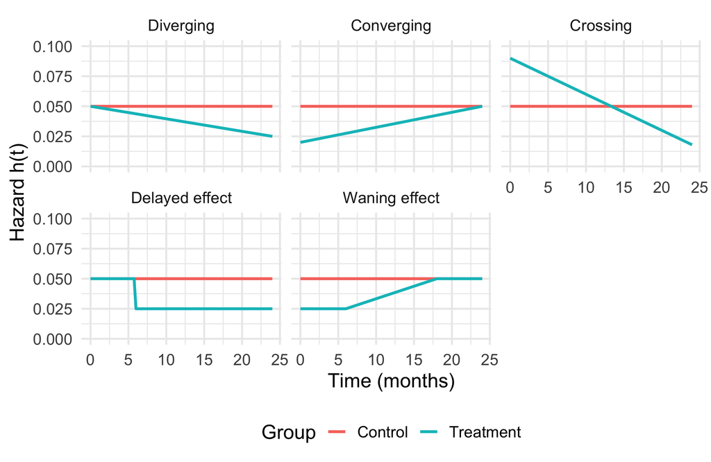

Stylised hazards. Only a constant ratio (a “parallel” pair on the log scale) satisfies PH.

## Medical situations

| Pattern | Typical situation |
| --- | --- |
| Diverging | Benefit builds up slowly, or a risk factor’s impact grows with time |
| Converging | Effect of a baseline factor (e.g. stage, performance status) fades as the high-risk patients die |
| Crossing | Surgery vs medical therapy: early operative risk, later benefit (Collett Figure 11.1) |
| Delayed effect | Immuno-oncology: the immune system needs months to respond; curves overlap initially |
| Wane of effect | Vaccine protection, or a drug effect that disappears after stopping treatment |

**Note**

In all five, “the hazard ratio” is a function $HR(t)$, not a number.

## Delayed effect: what the survival curves look like

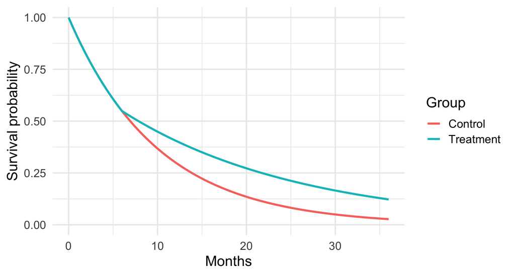

Same hazard $0.10$/month for 6 months; afterwards $0.05$ in the treatment arm (true $HR = 0.5$ after month 6).

## Why it matters: the Cox HR is an average

Under non-PH, the partial likelihood still gives an estimate $\hat\beta$, but it estimates a **weighted average of $\log HR(t)$**, where the weights depend on

- the number of events at each time (so on the **follow-up** and **censoring** pattern),
- the risk-set sizes.

So the “average HR” is **not a property of the treatment alone**: the same drug, studied with longer follow-up or different censoring, gives a different number.

Collett (Fig. 11.4, with Fig. 11.3 for strata): fitting a PH model to hazards that cross or diverge gives fitted hazards that describe neither phase of the effect.

## Simulation: delayed effect, different follow-up

True hazard ratio: $1$ for $t<6$ months, $0.5$ afterwards. Administrative censoring at different times.

```r
sim_delay <- function(n = 4000, followup) {
  e <- rexp(2 * n)
  grp <- rep(0:1, each = n)
  t <- ifelse(grp == 0, e / 0.1,
              ifelse(e < 0.6, e / 0.1, 6 + (e - 0.6) / 0.05))
  d <- data.frame(grp, time = pmin(t, followup), status = as.integer(t <= followup))
  fit <- coxph(Surv(time, status) ~ grp, data = d)
  c(followup = followup, HR = unname(exp(coef(fit))), events = sum(d$status))
}
res <- map_dfr(c(6, 12, 24, 48), \(f) as.list(sim_delay(followup = f)))
res |> mutate(HR = round(HR, 2))
```

```
# A tibble: 4 × 3
  followup    HR events
     <dbl> <dbl>  <dbl>
1        6  1      3635
2       12  0.82   5121
3       24  0.72   6727
4       48  0.71   7678
```

The estimated HR moves from about 1 (follow-up 6 months) to 0.71 (48 months), but it stays far from the true late HR of 0.5 even after 48 months. A single HR is a statement about the *trial*, not only the *drug*.

## Why it matters: three consequences

1. **Interpretation**: “HR = 0.7” has no clear meaning.
2. **Power**: the log-rank test loses power for late or crossing differences (for crossing curves it may be near zero).
3. **Generalisability**: results depend on follow-up, censoring and recruitment pattern.

**Important**

Non-PH is not a nuisance to be “fixed” by a test. It is **a finding about the treatment**: *when* the effect happens is clinically relevant.

# Detecting non-PH

## Example: gastric cancer trial (Collett Example 11.2)

Gastrointestinal Tumor Study Group: chemotherapy (`treat = 0`) vs chemotherapy + radiation (`treat = 1`)<sup>1</sup>, survival in days, n = 90.

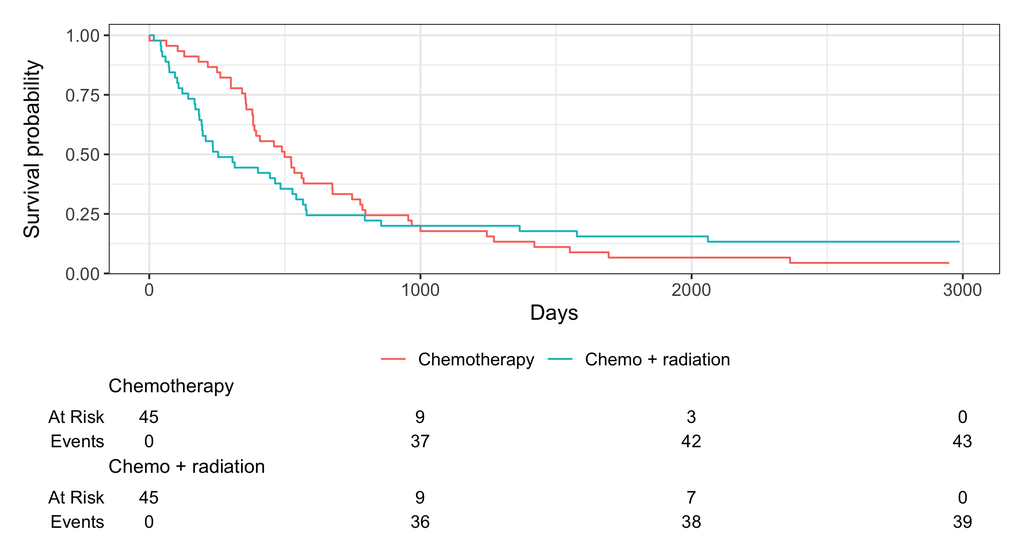

```r
survfit2(Surv(time, status) ~ arm, data = gastric) |>
  ggsurvfit() +
  add_risktable() +
  labs(x = "Days", y = "Survival probability")
```

The KM curves cross at about day 968 (first day where the radiation curve is back at or above the chemotherapy curve). Radiation has **more early deaths** and a **better long-term outlook**. Note that this is not the same as the day where the *hazard ratio* crosses 1, which comes earlier (see the `tt()` fit below).

[^1]: Collett defines X = 0 for chemotherapy alone and X = 1 for the combined treatment (Section 11.2), which is what the labels use.

## Checking the data coding

```r
table(gastric$arm, gastric$status, dnn = c("arm", "status (1 = death)"))
```

```
                   status (1 = death)
arm                  0  1
  Chemotherapy       2 43
  Chemo + radiation  6 39
```

```r
summary(gastric$time)
```

```
   Min. 1st Qu.  Median    Mean 3rd Qu.    Max.
    1.0   195.5   404.5   708.7   792.8  2988.0
```

82 of 90 patients died: heavily observed, with few censored (8). Follow-up reaches 2988 days, but very few patients are at risk beyond about 1000 days.

## Detecting: log-minus-log plot

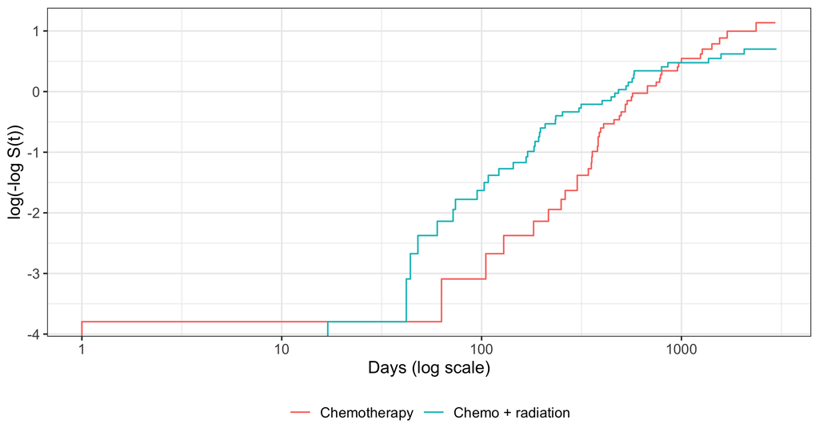

```r
survfit2(Surv(time, status) ~ arm, data = gastric) |>
  ggsurvfit(type = "cloglog") +
  labs(x = "Days (log scale)", y = "log(-log S(t))") +
  scale_x_log10()
```

Under PH the two curves are **parallel**. Here they cross.

## Detecting: `cox.zph` (recap of lecture 6)

```r
fit_g <- coxph(Surv(time, status) ~ treat, data = gastric)
cz <- cox.zph(fit_g, transform = "km")
cz
```

```
       chisq df       p
treat   13.2  1 0.00028
GLOBAL  13.2  1 0.00028
```

With `transform = "km"`, the test of a zero slope of the scaled Schoenfeld residuals against time gives $p =$ 0.00028: evidence against PH.

## Schoenfeld plot

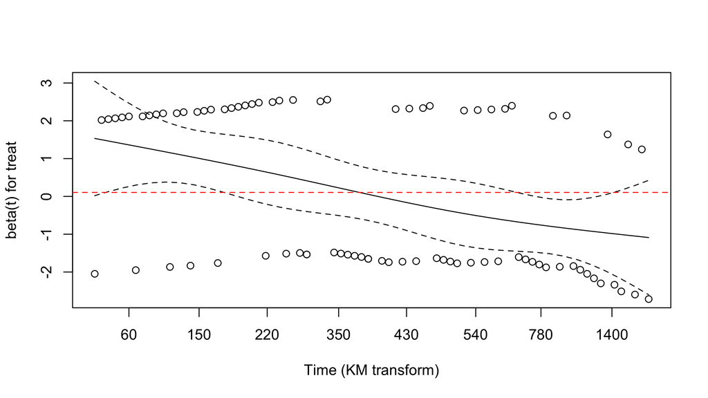

```r
plot(cz, resid = TRUE, xlab = "Time (KM transform)", ylab = "beta(t) for treat")
abline(h = coef(fit_g), lty = 2, col = "red")
```

The smooth is an estimate of $\beta(t)$: positive (harm) early, negative later. The dashed line is the single Cox estimate.

**Warning**

`cox.zph` has low power with few events and tests only one particular form of departure. **Look at the plot** and think about the mechanism.

## A second example: `veteran` (lung cancer trial)

```r
fit_v <- coxph(Surv(time, status) ~ trt + karno + age + celltype, data = veteran)
cox.zph(fit_v)
```

```
          chisq df       p
trt       0.284  1 0.59382
karno    12.977  1 0.00032
age       1.874  1 0.17099
celltype 14.884  3 0.00192
GLOBAL   29.179  6 5.6e-05
```

The Karnofsky score (performance status) shows non-PH (and `celltype` also departs from PH, which is why it is stratified below in Option 1). Illustration of the “converging” pattern: the prognostic value of a baseline score fades with time as the sickest patients die.

## Veteran: the effect of `karno` over time

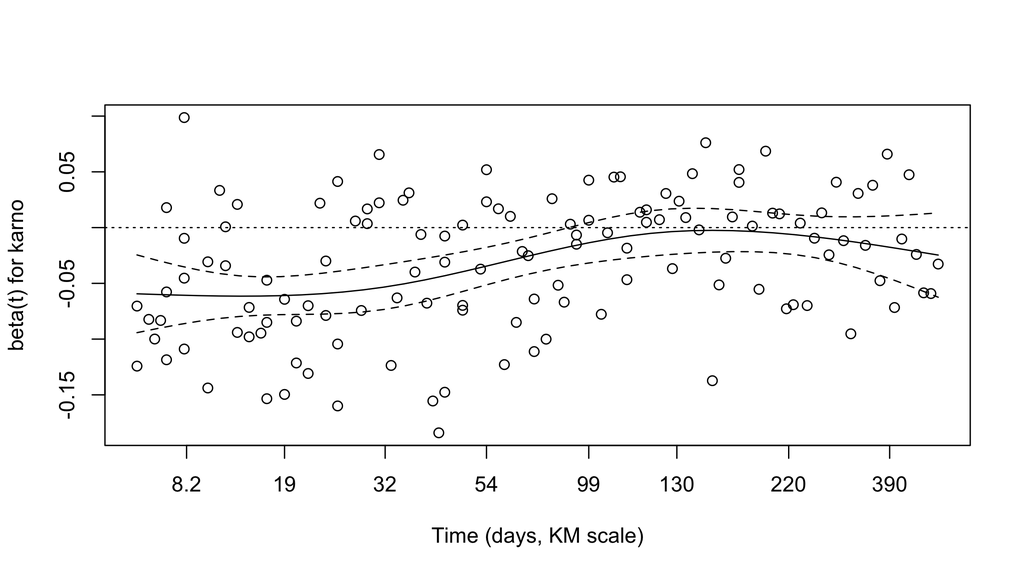

```r
plot(cox.zph(fit_v)[2], xlab = "Time (days, KM scale)", ylab = "beta(t) for karno")
abline(h = 0, lty = 3)
```

The coefficient is clearly negative early (higher score, lower hazard) and moves towards 0 later.

# Options for analysis

## Roadmap

```
flowchart LR
  A[Non-PH found] --> B{Nuisance variable<br/>or effect of interest?}
  B -->|Nuisance| C[1. Stratify]
  B -->|Of interest| D[2. Time-varying effect]
  B -->|Of interest| E[3. RMST / milestone survival]
  B -->|Test only| F[4. Weighted log-rank]
  B -->|Different scale| G[5. AFT]
```

[output not shown]

## Option 1: stratification

If the non-PH variable is a **nuisance** (a confounder, a centre), let it have its own baseline hazard:

$$h_j(t \mid x) = h_{0j}(t)\exp(\beta' x), \quad j = 1,\dots,J$$

```r
fit_vs <- coxph(Surv(time, status) ~ trt + karno + age + strata(celltype), data = veteran)
broom::tidy(fit_vs, exponentiate = TRUE, conf.int = TRUE) |>
  mutate(across(where(is.numeric), \(x) round(x, 3)))
```

```
# A tibble: 3 × 7
  term  estimate std.error statistic p.value conf.low conf.high
  <chr>    <dbl>     <dbl>     <dbl>   <dbl>    <dbl>     <dbl>
1 trt      1.34      0.207      1.40   0.16     0.891     2.01
2 karno    0.963     0.006     -6.53   0        0.952     0.974
3 age      0.988     0.01      -1.21   0.225    0.97      1.01
```

- No HR is estimated for `celltype`, and it cannot be tested
- Remaining covariates still need PH, and **same $\beta$** across strata is assumed
- Useless if the non-PH variable is the **treatment** of interest

## Option 2a: piecewise Cox (step function HR)

Assume PH within time intervals, with a different HR in each (Collett Eq. 11.3; mechanics of `survSplit()`: Lecture 10). Cut points as in Collett: 360, 720, 1080 days.

```r
cuts <- c(360, 720, 1080)
gs <- survSplit(Surv(time, status) ~ ., data = gastric, cut = cuts, episode = "interval")
gs$interval <- factor(gs$interval, labels = c("0-360", "361-720", "721-1080", ">1080"))
head(gs[, c("patient", "tstart", "time", "status", "treat", "interval")], 5)
```

```
  patient tstart time status treat interval
1       1      0    1      1     0    0-360
2       2      0   63      1     0    0-360
3       3      0  105      1     0    0-360
4       4      0  129      1     0    0-360
5       5      0  182      1     0    0-360
```

```r
table(gs$interval, gs$status)
```

```
            0  1
  0-360    51 39
  361-720  26 25
  721-1080 17  9
  >1080     8  9
```

Events per interval are few after day 720.

## Piecewise Cox: interval-specific HRs

```r
fit_pw <- coxph(Surv(tstart, time, status) ~ treat:interval, data = gs)
pw <- broom::tidy(fit_pw, exponentiate = TRUE, conf.int = TRUE) |>
  mutate(term = str_remove(term, "treat:interval")) |>
  select(interval = term, HR = estimate, conf.low, conf.high)
pw |> mutate(across(where(is.numeric), \(x) round(x, 2)))
```

```
# A tibble: 4 × 4
  interval    HR conf.low conf.high
  <chr>    <dbl>    <dbl>     <dbl>
1 0-360     2.4      1.25      4.63
2 361-720   0.78     0.34      1.76
3 721-1080  0.33     0.07      1.6
4 >1080     0.31     0.08      1.24
```

Interpretation: in the first year, radiation is associated with a hazard 2.4 times that of chemotherapy (95% CI 1.25 to 4.63), i.e. higher mortality. In later intervals the estimated HR is below 1, but with wide intervals (few events). These agree with Collett Table 11.3.

## Test for PH using the piecewise model

Compare the model with one common $\beta$ to the interval-specific model:

```r
fit_common <- coxph(Surv(tstart, time, status) ~ treat, data = gs)
anova(fit_common, fit_pw)
```

```
Analysis of Deviance Table
 Cox model: response is  Surv(tstart, time, status)
 Model 1: ~ treat
 Model 2: ~ treat:interval
   loglik Chisq Df Pr(>|Chi|)
1 -307.44
2 -301.15 12.57  3   0.005665 **
---
Signif. codes:  0 '***' 0.001 '**' 0.01 '*' 0.05 '.' 0.1 ' ' 1
```

The likelihood ratio test (3 df) is the formal test of “same HR in all intervals” for these cut points.

**Warning**

Cut points should be chosen **before** looking at the data, or based on clinical reasoning (e.g. “first year”). Data-driven cut points inflate type I error and make the intervals look more convincing than they are.

## Option 2b: HR as a function of time with `tt()`

Application of the time-varying coefficient $\beta(t) = \beta_0 + \beta_1 g(t)$, $g(t)=\log t$ (mechanics: Lecture 10), giving $HR(t) = \exp\{\beta_0 + \beta_1 \log t\}$.

```r
fit_tt <- coxph(Surv(time, status) ~ treat + tt(treat), data = gastric,
                tt = function(x, t, ...) x * log(t))
fit_tt
```

```
Call:
coxph(formula = Surv(time, status) ~ treat + tt(treat), data = gastric,
    tt = function(x, t, ...) x * log(t))

             coef exp(coef) se(coef)      z       p
treat      3.8662   47.7602   1.4771  2.617 0.00886
tt(treat) -0.6468    0.5237   0.2479 -2.609 0.00909

Likelihood ratio test=8.54  on 2 df, p=0.01396
n= 90, number of events= 82
```

`tt(treat)` is $\beta_1$; its estimate is -0.65, so the HR decreases with time (smooth monotone curve, 2 parameters).

## Plot the fitted $HR(t)$

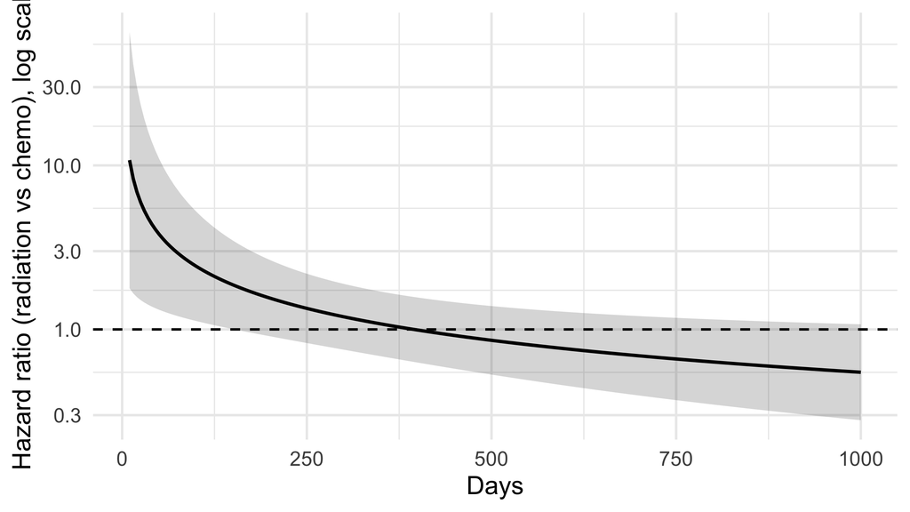

```r
b <- coef(fit_tt); V <- vcov(fit_tt)
tg <- seq(10, 1000, by = 5)
X <- cbind(1, log(tg))
est <- drop(X %*% b); se <- sqrt(rowSums((X %*% V) * X))
ggplot(tibble(t = tg, hr = exp(est), lo = exp(est - 1.96 * se), hi = exp(est + 1.96 * se)),
       aes(t, hr)) +
  geom_ribbon(aes(ymin = lo, ymax = hi), alpha = 0.2) + geom_line(linewidth = 1) +
  geom_hline(yintercept = 1, linetype = 2) + scale_y_log10() +
  labs(x = "Days", y = "Hazard ratio (radiation vs chemo), log scale")
```

HR is above 1 early and crosses 1 around day 395. The band is wide: the function is estimated from 82 events.

## Splines, and a warning

- More flexibility: other choices of $g(t)$ (Lecture 10)
- `rms`, `flexsurv` and Royston-Parmar models (Collett Section 6.4) allow treatment-by-time interactions in the baseline spline
- **Caution**: the model is only as good as the assumed functional form (here $\log t$); predictions from `tt()` models need care (Lecture 10)

**Tip**

Piecewise HRs are easy to explain to clinicians. Smooth $\beta(t)$ is more efficient. Report one, and say that the other was a sensitivity analysis.

## Option 3: a summary that does not need PH

Instead of modelling the hazard, **summarise the survival curves** directly:

- **Milestone survival**: $S(t^*)$, difference $\hat S_1(t^*) - \hat S_0(t^*)$ at a fixed time $t^*$
- **Restricted mean survival time**:
  $$\text{RMST}(\tau) = E\{\min(T,\tau)\} = \int_0^\tau S(u)\,du$$
  the area under the survival curve up to $\tau$: *average event-free time within the first $\tau$ days*.

Treatment effect: $\widehat{\text{RMST}}_1(\tau) - \widehat{\text{RMST}}_0(\tau)$, in days (or months) gained or lost.

- Needs no PH assumption, valid for crossing curves
- Collett Section 11.3

## RMST as an area

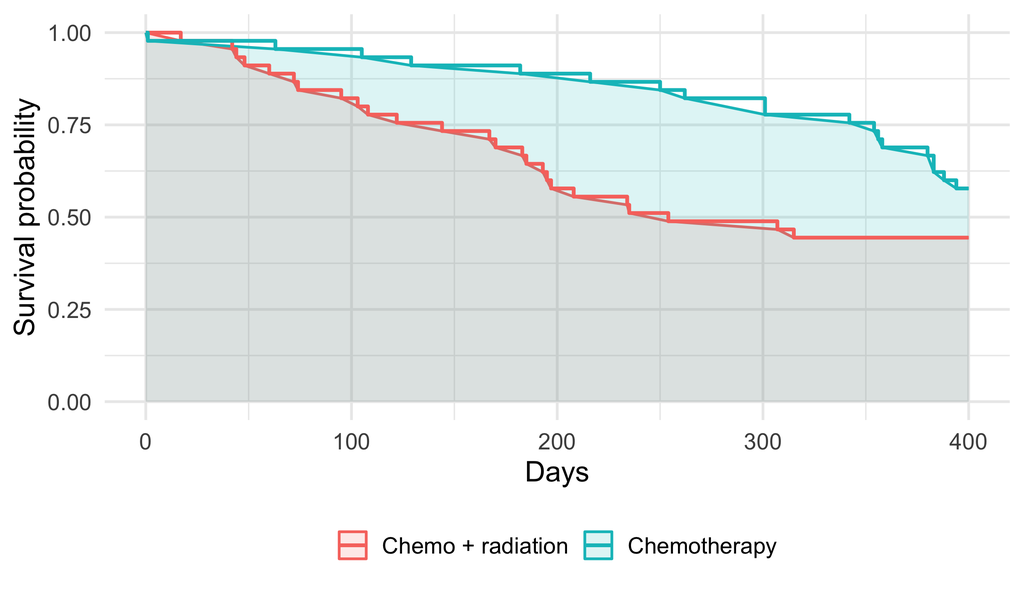

Shaded area up to $\tau = 400$ days = RMST. The gap between the areas is the difference in RMST.

## RMST in R: from `survfit`

```r
fit_km <- survfit(Surv(time, status) ~ arm, data = gastric)
print(fit_km, rmean = 400)
```

```
Call: survfit(formula = Surv(time, status) ~ arm, data = gastric)

                       n events rmean* se(rmean) median 0.95LCL 0.95UCL
arm=Chemotherapy      45     43    346      14.9    499     383     748
arm=Chemo + radiation 45     39    262      20.6    254     193     542
    * restricted mean with upper limit =  400
```

`rmean*` is the area under each KM curve up to $\tau=400$ days, with its standard error.

```r
tab <- summary(fit_km, rmean = 400)$table
mu <- tab[, "rmean"]; se <- tab[, "se(rmean)"]
d <- unname(mu[2] - mu[1]); sed <- sqrt(sum(se^2))
round(c(diff = d, lower = d - 1.96 * sed, upper = d + 1.96 * sed,
        z = d / sed, p = 2 * pnorm(-abs(d / sed))), 3)
```

```
    diff    lower    upper        z        p
 -83.911 -133.767  -34.055   -3.299    0.001
```

## Interpreting the RMST difference

Over the first 400 days, patients on chemotherapy alone lived on average 346 days, and patients on chemo + radiation 262 days. The difference (radiation minus chemotherapy) is -84 days (95% CI -134 to -34), $p =$ 0.00097.

- Plain scale: **days of life gained or lost within 400 days**
- The estimate is *not* a “hazard ratio” and is not meant to be: it describes the first 400 days only
- Independent (non-informative) censoring is still required
- Dedicated packages exist on CRAN (e.g. `survRM2`), but are not used here

**Note**

Same `se` formula as Collett p. 340: the RMST is the integral of $\hat S$, with a variance derived from the Greenwood-type formula.

## Milestone survival

```r
ms <- summary(fit_km, times = c(200, 400, 800))
tibble(arm = ms$strata, time = ms$time, S = ms$surv, se = ms$std.err,
       lower = ms$lower, upper = ms$upper) |>
  mutate(across(where(is.numeric), \(x) round(x, 3)))
```

```
# A tibble: 6 × 6
  arm                    time     S    se lower upper
  <fct>                 <dbl> <dbl> <dbl> <dbl> <dbl>
1 arm=Chemotherapy        200 0.889 0.047 0.802 0.986
2 arm=Chemotherapy        400 0.578 0.074 0.45  0.742
3 arm=Chemotherapy        800 0.244 0.064 0.146 0.409
4 arm=Chemo + radiation   200 0.578 0.074 0.45  0.742
5 arm=Chemo + radiation   400 0.444 0.074 0.321 0.616
6 arm=Chemo + radiation   800 0.222 0.062 0.129 0.384
```

Difference at a time $t^*$: $\hat S_1 - \hat S_0$ with $SE = \sqrt{SE_1^2 + SE_0^2}$ (independent groups).

```r
m <- tibble(time = ms$time, S = ms$surv, se = ms$std.err, g = as.character(ms$strata)) |>
  pivot_wider(names_from = g, values_from = c(S, se)) |>
  mutate(diff = `S_arm=Chemo + radiation` - `S_arm=Chemotherapy`,
         se_diff = sqrt(`se_arm=Chemo + radiation`^2 + `se_arm=Chemotherapy`^2),
         z = diff / se_diff)
m |> select(time, diff, se_diff, z) |> mutate(across(everything(), \(x) round(x, 3)))
```

```
# A tibble: 3 × 4
   time   diff se_diff      z
  <dbl>  <dbl>   <dbl>  <dbl>
1   200 -0.311   0.087 -3.56
2   400 -0.133   0.104 -1.28
3   800 -0.022   0.089 -0.249
```

Early on radiation is *worse* (200 and 400 days, $z<0$); by 800 days the survival probabilities are nearly equal (-0.022). The gap between the curves changes with time, which a single summary over all times would hide.

## Choice of $\tau$

- RMST depends on $\tau$; **fix it in the protocol**, not after seeing the curves
- Must satisfy $\tau \le$ the smaller of the largest observation times in the groups; and the KM curve must be stable there (enough patients at risk)
- Common rules: the time where at least 10-20% of patients are still at risk in each arm; a clinically meaningful horizon (e.g. 1, 2 or 5 years)

```r
taus <- c(200, 400, 600, 800)
map_dfr(taus, \(tau) {
  tb <- summary(fit_km, rmean = tau)$table
  dd <- unname(tb[2, "rmean"] - tb[1, "rmean"]); s <- sqrt(sum(tb[, "se(rmean)"]^2))
  tibble(tau = tau, rmst_chemo = tb[1, "rmean"], rmst_radiation = tb[2, "rmean"],
         diff = dd, se = s, z = dd / s)
}) |> mutate(across(everything(), \(x) round(x, 2)))
```

```
# A tibble: 4 × 6
    tau rmst_chemo rmst_radiation   diff    se     z
  <dbl>      <dbl>          <dbl>  <dbl> <dbl> <dbl>
1   200       188.           165.  -23.6  10.2 -2.32
2   400       346.           262.  -83.9  25.4 -3.3
3   600       443.           332. -110.   41.0 -2.69
4   800       511.           381. -129.   55.5 -2.33
```

The RMST difference is negative for every $\tau$ here, but its size and $z$-value **depend on $\tau$** (the area keeps accumulating the early deficit). Honest reporting fixes $\tau$ in advance, shows a few horizons as sensitivity, and shows the full curves.

## Option 4: weighted log-rank tests (recap lecture 3)

Fleming-Harrington $G^{\rho,\gamma}$: weight $w(t) = \hat S(t-)^\rho\{1-\hat S(t-)\}^\gamma$

| $(\rho,\gamma)$ | Emphasis |
| --- | --- |
| (0, 0) | log-rank, equal weight, best under PH |
| (1, 0) | early differences (Peto-Peto type) |
| (0, 1) | **late** differences, used for delayed effects |

```r
survdiff(Surv(time, status) ~ arm, data = gastric, rho = 0)
```

```
Call:
survdiff(formula = Surv(time, status) ~ arm, data = gastric,
    rho = 0)

                       N Observed Expected (O-E)^2/E (O-E)^2/V
arm=Chemotherapy      45       43     45.1    0.0992     0.225
arm=Chemo + radiation 45       39     36.9    0.1213     0.225

 Chisq= 0.2  on 1 degrees of freedom, p= 0.6
```

```r
survdiff(Surv(time, status) ~ arm, data = gastric, rho = 1)
```

```
Call:
survdiff(formula = Surv(time, status) ~ arm, data = gastric,
    rho = 1)

                       N Observed Expected (O-E)^2/E (O-E)^2/V
arm=Chemotherapy      45     20.0     25.4      1.16      3.96
arm=Chemo + radiation 45     25.2     19.7      1.50      3.96

 Chisq= 4  on 1 degrees of freedom, p= 0.05
```

`survdiff()` only offers $G^{\rho,0}$. For $\gamma>0$ other packages exist on CRAN; they are not used here.

## Weighted log-rank: caveats

- Gives a **p-value**, not an effect size; no CI for a treatment effect
- The weight must be **pre-specified**. Choosing $\rho,\gamma$ after seeing the plots is cherry-picking
- With crossing curves the early and late differences partly cancel, so ordinary log-rank has low power. A *max-combo* test (several weights, adjust for multiplicity) is a robust compromise
- Pair a weighted test with a descriptive measure (RMST, milestone survival)

**Tip**

Typical analysis plan in a delayed-effect trial: log-rank (or max-combo) as primary test, RMST difference as the effect estimate.

## Option 5: AFT models

Accelerated failure time (lecture 8): $\log T = \mu + \alpha' x + \sigma\varepsilon$. Effects are **time ratios**, not hazard ratios.

- Weibull with a **common** shape is both PH and AFT, so it cannot fit crossing curves
- Log-logistic: hazards *converge* (non-PH) and the model has proportional odds
- Allowing a **different scale** per group gives different shapes, so hazards may cross

```r
fit_w <- survreg(Surv(time, status) ~ treat + strata(treat), data = gastric, dist = "weibull")
fit_w
```

```
Call:
survreg(formula = Surv(time, status) ~ treat + strata(treat),
    data = gastric, dist = "weibull")

Coefficients:
(Intercept)       treat
  6.6506562  -0.1091565

Scale:
  treat=0   treat=1
0.9132134 1.4287207

Loglik(model)= -622.6   Loglik(intercept only)= -622.7
    Chisq= 0.16 on 1 degrees of freedom, p= 0.69
n= 90
```

The scale parameters differ between arms (strata `treat=0` and `treat=1`), so the fitted hazards are non-proportional and can cross. Time ratios then depend on the quantile of interest: again no single number.

## Which option when?

| Aim | Suggested approach |
| --- | --- |
| Non-PH covariate is a nuisance | Stratify |
| Describe how the effect changes with time | Piecewise HR or $\beta(t)$ via `tt()` |
| One interpretable effect summary | RMST difference / milestone survival (pre-specify $\tau$) |
| Test with expected delayed effect | Weighted log-rank / max-combo |
| Parametric extrapolation, covariates | Flexible parametric or AFT models |

Always: plot the KM curves with risk table first.

# Institutional comparisons

## Comparing hospitals and centres

Medical question: **do transplant centres (hospitals, surgeons) differ in outcome after taking account of patient mix?**

- Registries and regulators publish “performance indicators”, e.g. risk-adjusted mortality
- Centres treat different patients: older donors, diabetics, long cold ischaemic times…
- Raw outcomes mix **quality of care** with **case mix**

Goal: compare each centre with what would be expected **if its patients had been treated at an average centre**.

Collett Section 11.4; the same methods apply to schools, surgeons, or financial providers.

## Data: UK kidney transplant centres

Transplants from deceased donors in 8 centres (2009-2011), follow-up to December 2012.

```r
head(kidney, 4)
```

```
  patient centre tsurv tcens dage dtype rage diab  cit
1       1      6  1384     0   63     0   44    0 25.3
2       2      8  1446     0   17     0   33    0 24.0
3       3      8  1414     0   34     0   48    0 16.7
4       4      5  1459     0   36     0   31    0 13.6
```

```r
table(kidney$tcens)
```

```
   0    1
1233  206
```

By the chapter’s data description: `tsurv` = transplant survival time (days), `tcens` = **event indicator** (1 = transplant failure, 0 = censored; the name is misleading). Check: 206 events among 1439 patients, 35 with `tsurv = 0` (graft never functioned).

## Raw one-year failure by centre

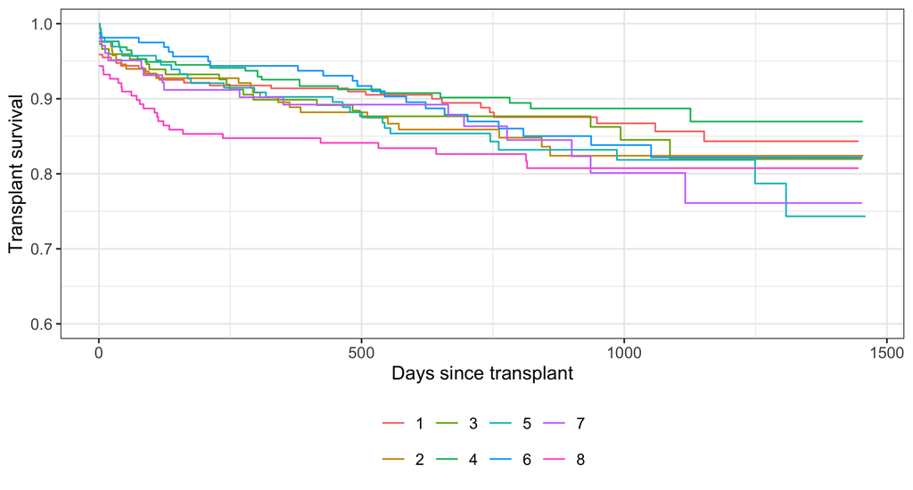

```r
survfit2(Surv(tsurv, tcens) ~ centre, data = kidney) |>
  ggsurvfit() +
  labs(x = "Days since transplant", y = "Transplant survival") +
  scale_y_continuous(limits = c(0.6, 1)) +
  coord_cartesian(xlim = c(0, 1460))
```

Unadjusted curves differ somewhat. Is it the centre, or the patients?

## Case mix differs between centres

```r
kidney |>
  group_by(centre) |>
  summarise(n = n(), events = sum(tcens), donor_age = mean(dage), DCD = mean(dtype),
            recip_age = mean(rage), diabetic = mean(diab), CIT = mean(cit)) |>
  mutate(across(where(is.numeric) & !c(n, events), \(x) round(x, 2)))
```

```
# A tibble: 8 × 8
  centre     n events donor_age   DCD recip_age diabetic   CIT
  <fct>  <int>  <int>     <dbl> <dbl>     <dbl>    <dbl> <dbl>
1 1        267     33      53.2  0.72      52.8     0.08  13.9
2 2        166     25      47.3  0.46      52.0     0.05  16.1
3 3        148     21      46.8  0.3       50.4     0.05  12.9
4 4        255     27      49.6  0.38      49.9     0.09  15.5
5 5        164     28      51.3  0.53      50.2     0.13  14.9
6 6        160     23      48.3  0.47      54.0     0.11  15.4
7 7        102     17      53.6  0.42      55.0     0.1   16.4
8 8        177     32      46.6  0.24      48.0     0     17.4
```

Donor age, donor type, cold ischaemic time vary across centres: a centre receiving riskier organs will look worse.

## Step 1: the risk-adjustment model

Fit a Cox model with **patient-level** risk factors, *without* centre, to all centres combined:

```r
fit_ra <- coxph(Surv(tsurv, tcens) ~ dage + dtype + rage + diab + cit, data = kidney)
broom::tidy(fit_ra, exponentiate = TRUE, conf.int = TRUE) |>
  mutate(across(where(is.numeric), \(x) round(x, 3)))
```

```
# A tibble: 5 × 7
  term  estimate std.error statistic p.value conf.low conf.high
  <chr>    <dbl>     <dbl>     <dbl>   <dbl>    <dbl>     <dbl>
1 dage     1.02      0.005     4.31    0        1.01       1.03
2 dtype    1.21      0.143     1.34    0.179    0.915      1.61
3 rage     1.00      0.006     0.315   0.753    0.99       1.01
4 diab     0.873     0.269    -0.503   0.615    0.516      1.48
5 cit      1.02      0.015     1.04    0.298    0.986      1.05
```

Our coefficient for `dage` is 0.024 per year (Collett reports 0.023 in the fitted risk score, Section 11.4): HR per 10 years of donor age is about 1.27.

## Direct approach: centre as a covariate

Add centre as a factor, adjusted for case mix:

```r
fit_c <- coxph(Surv(tsurv, tcens) ~ centre + dage + dtype + rage + diab + cit, data = kidney)
broom::tidy(fit_c, exponentiate = TRUE, conf.int = TRUE) |>
  filter(str_detect(term, "centre")) |>
  mutate(across(where(is.numeric), \(x) round(x, 2)))
```

```
# A tibble: 7 × 7
  term    estimate std.error statistic p.value conf.low conf.high
  <chr>      <dbl>     <dbl>     <dbl>   <dbl>    <dbl>     <dbl>
1 centre2     1.59      0.27      1.69    0.09     0.93      2.71
2 centre3     1.53      0.29      1.47    0.14     0.87      2.7
3 centre4     1.04      0.27      0.13    0.89     0.62      1.74
4 centre5     1.52      0.26      1.61    0.11     0.91      2.52
5 centre6     1.35      0.28      1.07    0.28     0.78      2.32
6 centre7     1.5       0.31      1.32    0.19     0.82      2.73
7 centre8     2.12      0.27      2.79    0.01     1.25      3.59
```

HRs are relative to **centre 1**, an arbitrary reference. Centre 8 has HR 2.12, but all intervals are fairly wide.

```r
anova(fit_ra, fit_c)
```

```
Analysis of Deviance Table
 Cox model: response is  Surv(tsurv, tcens)
 Model 1: ~ dage + dtype + rage + diab + cit
 Model 2: ~ centre + dage + dtype + rage + diab + cit
   loglik  Chisq Df Pr(>|Chi|)
1 -1433.3
2 -1427.6 11.282  7     0.1268
```

The likelihood-ratio test for “no centre effect” has $p =$ 0.13.

## Cox with centre factor: pros and cons

- Simple, adjusted HRs with CIs
- Assumes PH of centre effects and that the covariate effects are the same in all centres
- Comparison with an **arbitrary reference centre**, not with “average performance”
- Alternative: **stratify by centre**, `strata(centre)`, to let baseline hazards differ, and estimate case-mix coefficients within centre; but then no centre effect is estimated

```r
coef(coxph(Surv(tsurv, tcens) ~ strata(centre) + dage + dtype + rage + diab + cit, data = kidney)) |>
  round(3)
```

```
  dage  dtype   rage   diab    cit
 0.026  0.295  0.002 -0.087  0.009
```

Case-mix coefficients are similar to the pooled model above, which supports the use of a common risk model.

## Step 2: observed vs expected failures at one year

For each patient $i$ in centre $j$, expected failures to time $\min(t_i, 365)$ is the estimated cumulative hazard $\hat H_{ij}$ (Collett Eq. 11.8):

$$e_j = \sum_{i \in j} \hat H_{ij}(\min(t_i, 365)) = \sum_{i \in j} \hat H_0(\min(t_i,365))\, e^{\hat\eta_i}$$

```r
bh <- basehaz(fit_ra, centered = FALSE)
H0 <- stepfun(bh$time, c(0, bh$hazard))
lp <- predict(fit_ra, type = "lp", reference = "zero")
kidney$expected <- H0(pmin(kidney$tsurv, 365)) * exp(lp)
kidney$obs1y <- as.integer(kidney$tcens == 1 & kidney$tsurv <= 365)
oe <- kidney |> group_by(centre) |>
  summarise(n = n(), observed = sum(obs1y), expected = sum(expected))
oe |> mutate(`O/E` = observed / expected) |> mutate(across(where(is.numeric), \(x) round(x, 2)))
```

```
# A tibble: 8 × 5
  centre     n observed expected `O/E`
  <fct>  <dbl>    <dbl>    <dbl> <dbl>
1 1        267       23     29.1  0.79
2 2        166       18     15.0  1.2
3 3        148       15     12.5  1.2
4 4        255       19     24.3  0.78
5 5        164       16     16.7  0.96
6 6        160        9     15.4  0.58
7 7        102       11     10.7  1.03
8 8        177       27     14.7  1.83
```

The model-based totals (Collett Table 11.6: centre 1, 23 observed and 28.96 expected) agree closely.

## Step 3: risk-adjusted failure rate (RAFR)

$$\text{RAFR}_j = \frac{\text{observed}_j}{\text{expected}_j} \times \text{overall failure rate}$$

```r
overall <- 1 - summary(survfit(Surv(tsurv, tcens) ~ 1, data = kidney), times = 365)$surv
oe <- oe |>
  mutate(RAFR = observed / expected * overall,
         lower = qgamma(0.025, observed) / expected * overall,
         upper = qgamma(0.975, observed + 1) / expected * overall)
oe |> select(centre, observed, expected, RAFR, lower, upper) |>
  mutate(across(where(is.numeric), \(x) round(x, 3)))
```

```
# A tibble: 8 × 6
  centre observed expected  RAFR lower upper
  <fct>     <dbl>    <dbl> <dbl> <dbl> <dbl>
1 1            23     29.1 0.076 0.048 0.114
2 2            18     15.0 0.116 0.068 0.183
3 3            15     12.5 0.115 0.065 0.19
4 4            19     24.3 0.075 0.045 0.117
5 5            16     16.7 0.092 0.053 0.149
6 6             9     15.4 0.056 0.026 0.107
7 7            11     10.7 0.099 0.049 0.177
8 8            27     14.7 0.177 0.116 0.257
```

Overall one-year failure rate: 0.096. Intervals use the exact Poisson limits (Collett Section 11.4.1); they should resemble Collett Table 11.7.

## Caterpillar plot

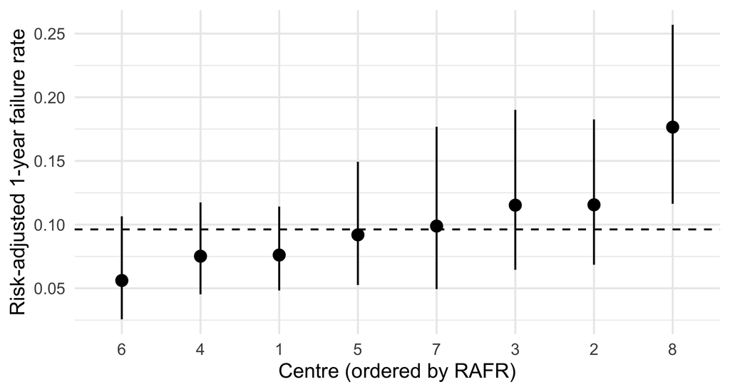

```r
ggplot(oe, aes(reorder(centre, RAFR), RAFR)) +
  geom_pointrange(aes(ymin = lower, ymax = upper)) +
  geom_hline(yintercept = overall, linetype = 2) +
  labs(x = "Centre (ordered by RAFR)", y = "Risk-adjusted 1-year failure rate")
```

Dashed: overall failure rate. Only centre 8 has an interval clearly above it; the other centres cannot be told apart reliably.

## RAFR and the Poisson model (pointer)

Collett (Section 11.4.2) shows the same estimates from a Poisson regression with offset $\log\{e_j/\text{overall rate}\}$ and one parameter per centre:

$$\log \mu_j = c_j + \log\{e_j / \text{overall rate}\}, \qquad \text{RAFR}_j = \exp(\hat c_j)$$

- With $J$ centres and $J$ parameters, the fit is perfect; the model only provides a convenient way to get the CIs
- Equivalent to a **standardised ratio** $O_j/E_j$ (SMR-type), rescaled to the overall rate

## Funnel plot

Idea: plot $O_j/E_j$ against a precision measure ($E_j$). Under “no centre effect”, $O_j \sim \text{Poisson}(E_j)$, so the scatter should lie inside **control limits** that narrow as $E_j$ grows.

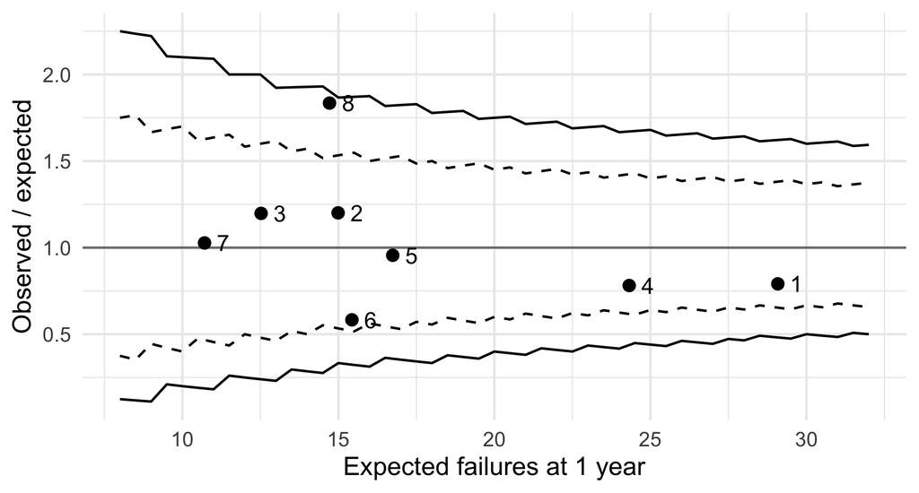

```r
E <- seq(8, 32, by = 0.5)
lim <- tibble(E = E,
              lo95 = qpois(0.025, E) / E, hi95 = qpois(0.975, E) / E,
              lo998 = qpois(0.001, E) / E, hi998 = qpois(0.999, E) / E)
ggplot(oe, aes(expected, observed / expected)) +
  geom_line(data = lim, aes(E, lo95), linetype = 2) + geom_line(data = lim, aes(E, hi95), linetype = 2) +
  geom_line(data = lim, aes(E, lo998)) + geom_line(data = lim, aes(E, hi998)) +
  geom_hline(yintercept = 1, colour = "grey50") +
  geom_point(size = 3) + geom_text(aes(label = centre), nudge_x = 0.6, size = 5) +
  labs(x = "Expected failures at 1 year", y = "Observed / expected")
```

Dashed: approx. 95%; solid: approx. 99.8% limits. Large centres are held to a stricter standard than small ones.

## Cautions about ranking institutions

- **League tables over-interpret noise**: with 8 centres there is always a “best” and a “worst”
- Ranks are very uncertain; an interval for the *rank* is usually wide
- Multiple comparisons: with many institutions, some will fall outside 95% limits by chance (use 99.8% limits, or shrinkage)
- Risk adjustment only removes **measured** case mix (residual confounding, e.g. selection of patients, unmeasured frailty)
- Small centres have unstable estimates
- Over-dispersion: true differences between centres make limits too narrow
- Gaming: centres may avoid high-risk patients

**Warning**

“Centre X is an outlier” is a reason to *investigate*, not a verdict on quality.

## Pointer: random institution effects

- With **many** institutions, fixed centre effects are noisy
- Treat institution effects as random: a **shared frailty** model $h_{ij}(t) = z_j h_0(t) e^{\beta' x_{ij}}$ with $z_j$ gamma distributed; estimates are shrunk towards the overall mean (Collett Section 11.4.3); unobserved heterogeneity between institutions is the motivation
- Frailty models: **Lecture 15**

## Non-PH in institutional comparisons

- A centre effect may be larger early (surgical complications) than late
- Check PH for the centre factor:

```r
cox.zph(fit_c, terms = TRUE)
```

```
         chisq df     p
centre 18.0119  7 0.012
dage    0.0457  1 0.831
dtype   0.1569  1 0.692
rage    0.9551  1 0.328
diab    3.0235  1 0.082
cit     1.4188  1 0.234
GLOBAL 22.4083 12 0.033
```

- Here `cox.zph` gives $p =$ 0.012 for the centre factor: some evidence that centre differences change with time, though with 8 levels the power is spread and the test is crude
- The **fixed-time** RAFR at one year is itself a milestone-survival summary and does not need PH for the centre effect, but it needs a risk model that fits to 365 days

# Exercise and take-home

## In-class exercise (10 min)

Using the `gastric` data:

1. Compute the RMST for each arm with $\tau = 600$ days and the difference with 95% CI.
2. Compute survival at 600 days in each arm. Do the two summaries tell the same story?
3. Run `survdiff()` with `rho = 0` and `rho = 1`. Why might they differ for these data?
4. Which analysis would you pre-specify in a trial protocol if you expected crossing curves from earlier trials? Why?

*Extra*: In the kidney data, repeat the RAFR calculation at **two years** (730 days). Do the centre conclusions change?

## Quiz

Which statements are true?

1. The Cox HR under non-PH is the same however long the follow-up is.
2. RMST requires the proportional hazards assumption.
3. Stratifying by centre estimates a hazard ratio for each centre.
4. If cox.zph gives $p>0.05$, PH holds.

All four are **false**: (a) it depends on the censoring pattern; (b) it does not; (c) stratified models give no centre effects; (d) absence of evidence is not evidence of absence (low power).

## Take-home messages

- Non-PH (diverging, converging, crossing, delayed, waning) means the HR is a **function of time**; a single Cox HR is a follow-up-dependent average
- Detect with KM plots, log-minus-log plots, Schoenfeld plots and `cox.zph()`, but think about the **mechanism**
- Options: **stratify** (nuisance), **piecewise / `tt()`** (describe $HR(t)$), **RMST and milestone survival** (assumption-light summaries; choose $\tau$ in advance), **weighted log-rank** (test), **AFT**
- Institutional comparisons: adjust for case mix with a Cox model, compare **observed to expected** failures (RAFR), show uncertainty (funnel plot); rankings are fragile
- Random institution effects: frailty models, Lecture 15

**Next lecture**: competing risks (Collett Chapter 12)

**Reading**: Collett, Chapter 11 (Sections 11.1-11.4; for 11.3.1, pseudo-values, see the chapter if interested)